# statistics project

faeze

2024-11-30

# پروژه درس آزمایشگاه آماری

ابتدا پکیج های مورد نیاز را فراخوانی میکنیم.

```r
library(car)
library(e1071)
```

حالا داده های خواسته شده را از آن فراخوانی میکنیم.

```r
data(Salaries)
```

نمونه خواسته شده را بدست اورده و سپس مقادیر خواسته شده را بدست می آوریم

```r
my.id=(79)+20
set.seed(my.id)
sample_data <- Salaries[sample(1:nrow(Salaries), my.id, replace = TRUE), ]
service_years_sample <- sample_data$yrs.service
```

حال شاخص های تمرکز (میانگین و میانه) را محاسبه میکنیم

```r
miangin <- mean(service_years_sample)#میانگین
miangin
```

```
## [1] 18.36364
```

```r
miane<- median(service_years_sample) #میانه
miane
```

```
## [1] 15
```

سپس شاخص های پراکندگی(انحراف معیار و واریانس و دامنه تغییرات) را محاسبه میکنیم

```r
enheraf_meyar<- sd(service_years_sample) #انحراف معیار
enheraf_meyar
```

```
## [1] 12.72428
```

```r
varians<- var(service_years_sample) #واریانس
varians
```

```
## [1] 161.9072
```

```r
damane_taghirat <- range(service_years_sample) #دامنه تغییزات
damane_taghirat
```

```
## [1]  0 57
```

حالا چارک های اول دوم و سوم را محاسبه میکنیم

```r
quartiles <- quantile(service_years_sample, probs = c(0.25, 0.5, 0.75))

print(quartiles)
```

```
## 25% 50% 75%
##   8  15  28
```

با توجه به چندک ها قابل مشاهده است که مقدار 25% داده ها کمتر از 8 و مقدار 50% داده ها کمتر از 15 و مقدار 75% داده ها کمتر از 28 است.

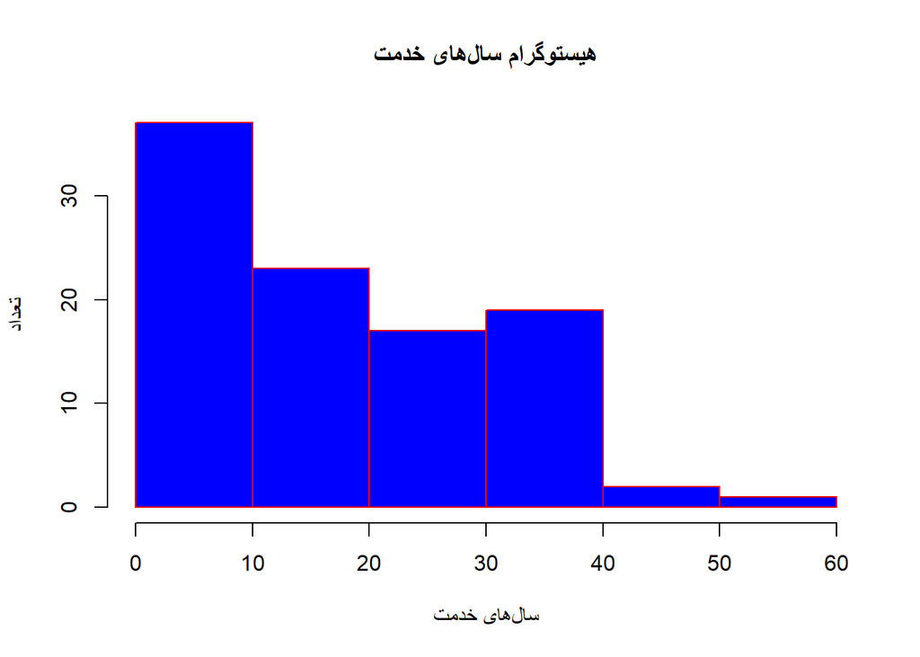

```r
hist(service_years_sample,
     main = "هیستوگرام سال‌های خدمت",
     xlab = "سال‌های خدمت",
     ylab = "تعداد",
     col = "blue",
     border = "red",
     breaks = "Sturges")
```

سوال دوم:

بار دیگر مانند سوال قبل پکیج هارا فراخوانی کرده و سپس از انها نمونه گیری میکنیم

```r
library(car)
library(e1071)
data(Salaries)
my.id <- 79 + 20
set.seed(my.id)
sample_data <- Salaries[sample(1:nrow(Salaries), my.id, replace = TRUE), ]
```

از انجایی که متغیر اول حاوی مقادیر کیفی است نمودار دایره ای ان را رسم میکنیم

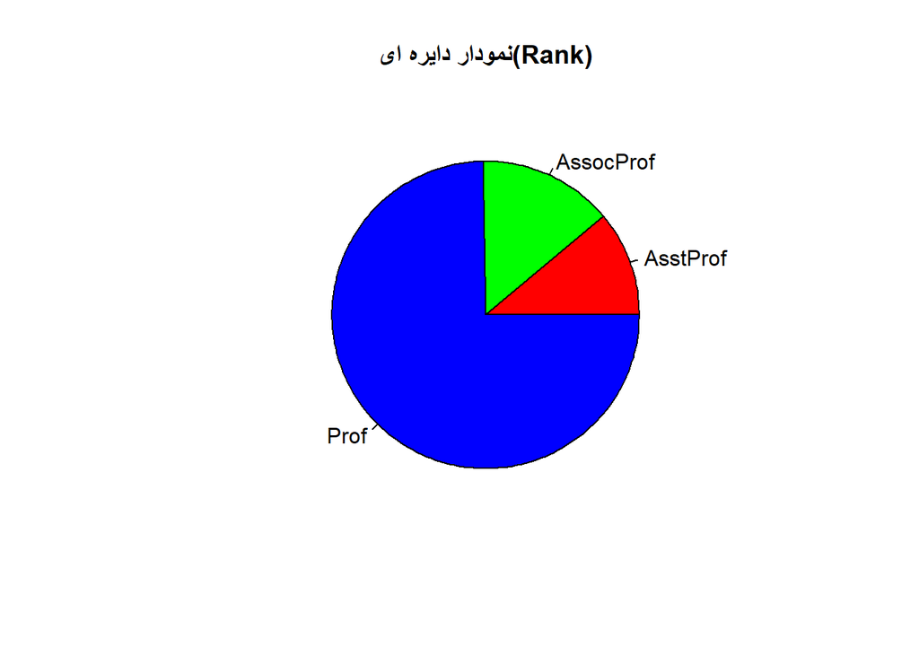

```r
rank_nemoodar<- table(sample_data$rank)
pie(rank_nemoodar,
    main = "نمودار دایره ای(Rank)",
    col = rainbow(length(rank_nemoodar)))
```

از انجایی که متفیر دوم حاوی مقادیر کمی است پس از نمودار هیستوگرام استفاده میکنیم

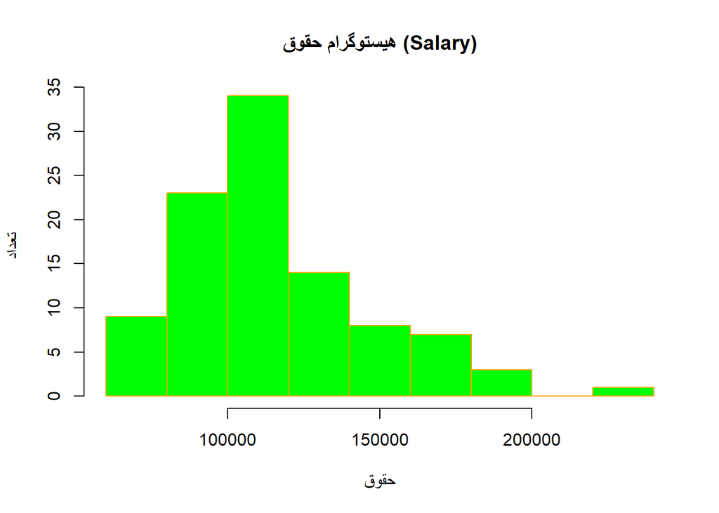

```r
hist(sample_data$salary,
     main = "هیستوگرام حقوق (Salary)",
     xlab = "حقوق",
     ylab = "تعداد",
     col = "green",
     border = "orange",
     breaks = "Sturges")
```

سوال سوم:

در این سوال قصد داریم با توزیع نرمال اعددادی که مضربی از 6 هستند را تولید کنیم. در ابتدا 100 عدد تصادفی را با استفاده از توزیع نرمال تولید میکنیم و انها را گرد میکنیم تا اعداد به شش نزدیک تر شوند

```r
my.id=(79)+20
set.seed(my.id)
normal_data <- rnorm(100, mean = 50, sd = 10)
rounded_data <- round(normal_data)
```

حالا مضارب 6 را استخراج میکنیم

```r
mazrab_6<- rounded_data[rounded_data %% 6 == 0]
print(mazrab_6)
```

```
##  [1] 54 36 36 48 36 36 48 54 48 54 42 42 54
```

سوال چهارم: در این سوال تنها کافیست با توجه به داده های سوال 1. یک تابع تعریف کنیم:

```r
my.id=(79)+20
set.seed(my.id)
f <- function(salaries) {
  n <- length(salaries)
  total_inverse <- sum(1 / salaries)
  result <- n / total_inverse
  return(result)
}
output <- f(sample_data$salary)
print(output)
```

```
## [1] 108374.1
```

سوال پنجم: در این سوال از ما حاصل انتگرال ها را میخواهند انتگرال اول را بدست می اوریم

```r
my.id <- 79 + 20
set.seed(my.id)
first_integral <- integrate(function(x) (1 + x^2), lower = 0.5, upper = 3)
first_integral
```

```
## 11.45833 with absolute error < 1.3e-13
```

حالا انتگرال دوگانه را محاسبه میکنیم(دقت داریم که دستور انتگرال دو گانه در پکیج pracma موجود است. پس ابتدا باید پکیج را فراخوانی کنیم)

```r
library(pracma)
second_integral<- function(x,y) (x + (y^2) -1)
integral2(second_integral, 3,5,0,1)
```

```
## $Q
## [1] 6.666667
##
## $error
## [1] 6.661338e-16
```

سوال ششم:

ابتدا دترمینان ماتریس را حساب میکنیم

```r
my.id <- 79 + 20
set.seed(my.id)
a<- matrix(c(1,6,9,2,1,5,4,3,3), nrow = 3, ncol = 3)
a
```

```
##      [,1] [,2] [,3]
## [1,]    1    2    4
## [2,]    6    1    3
## [3,]    9    5    3
```

```r
det(a)
```

```
## [1] 90
```

حالا معکوس ان را محاسبه میکنیم

```r
solve(a)
```

```
##            [,1]       [,2]        [,3]
## [1,] -0.1333333  0.1555556  0.02222222
## [2,]  0.1000000 -0.3666667  0.23333333
## [3,]  0.2333333  0.1444444 -0.12222222
```

در نهایت:

```r
diag(a) <- 0
a
```

```
##      [,1] [,2] [,3]
## [1,]    0    2    4
## [2,]    6    0    3
## [3,]    9    5    0
```